# NotebookとMarkdownをPresentationにした件

Jupyter NotebookをPresentationにする。

まずは機能の表示を確認しよう！

# Header 1

## Header 2

### Header 3

#### Header 4

- Item A
- Item B
- Item C
- Item D
1. Item i
2. Item ii
3. Item iii
4. Item ix

# では実際にコードを書いてみよう！

## 適当なデータセット

ここで、numpyとpandasを用いて適当なデータセットを作成する。 今回は単純に100名の生徒の数学・国語・英語・社会のテスト結果を作成する。

```python
df = pd.DataFrame(np.random.randint(0,100,size=(100, 4)), columns=list('数国英社'))
display.display(df.head())
```

|  | 数 | 国 | 英 | 社 |
| --- | --- | --- | --- | --- |
| 0 | 1 | 38 | 29 | 53 |
| 1 | 81 | 72 | 62 | 72 |
| 2 | 29 | 66 | 77 | 95 |
| 3 | 43 | 30 | 96 | 52 |
| 4 | 9 | 47 | 94 | 24 |

## DataframeのShapeを確認

簡単にDataframeのShapeの出力する。

```python
display.display(df.shape)
```

```
(100, 4)
```

以上の結果から100名生徒の4科目のデータセットが確認できる。

## 可視化する

可視化する関数を適当に作りましょう。

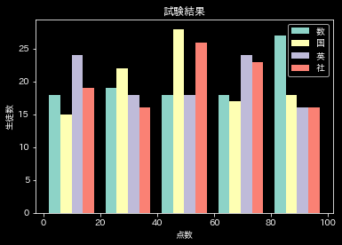

```python
show(df)
```

以上のプロットは100名生徒の４科目の点数の分布となる。

# 適当にSKLEARNを使ってみよう！

sklearnのdecompositionモジュールのPCA関数を使って、簡単に固有値ベクトルを計算し、 KMeans法を使ってクラスタリングをしてみよう！

```python
from sklearn.decomposition import PCA

pca = PCA(n_components=3)
pca.fit(df.values)
```

```
PCA(n_components=3)
```

```python
display.display(pca.components_)
```

```
array([[-0.67965175,  0.2263222 ,  0.57204697, -0.39951723],
       [-0.40736818, -0.63057073, -0.51952202, -0.40807915],
       [ 0.54617152, -0.47324164,  0.51138521, -0.46499912]])
```

```python
kmeans = KMeans(n_clusters=3, random_state=0).fit(df.values)
```

```python
display.display(kmeans.cluster_centers_)
```

```
array([[21.32432432, 56.45945946, 54.21621622, 41.27027027],
       [71.64285714, 36.21428571, 71.85714286, 45.57142857],
       [70.14285714, 52.68571429, 21.88571429, 63.97142857]])
```

## 注意点

printすることは要注意！ NotebookのプレゼンモードはHTML形式で行われるので、できれば**IPythonモジュールのdisplay関数**を使いましょう！

```python
display.display("What is this?")
```

```
'What is this?'
```

```python
print("What is this?")
```

```
What is this?
```

# 画像を追加する

画像を追加する時は普通のNotebookと全く一緒で、ただ表示すればよい。 ただし、実際のプレゼンの画面はサイズの制限があると感じるので、 そこは上手く調整しましょう！

```python
display.display(display.Image("../input/image.jpg", width=200, height=200))
```

[output not shown]

```python
display.display(display.Image("../input/image.jpg", width=400, height=400))
```

[output not shown]

```python
display.display(display.Image("../input/image.jpg", width=640, height=480))
```

[output not shown]